# Coral and Microplastics

- Home
- Background
- Preprocessing
- Model Building
- Results/Discussion
- References

# PREPROCESSING

These functions load and clean the raw coral cover and microplastics datasets before analysis. The coral function filters the dataset to include only hard coral observations, converts relevant columns to numeric values, and removes incomplete records. The microplastics function similarly filters the data to samples collected in the Coral Sea, converts concentrations and latitude to numeric values, and removes invalid entries. Together, these steps ensure that only consistent, usable data are passed into the model for estimating region-specific initial conditions.

```python
def load_coral_data(path):
    """Load and clean AIMS coral cover data."""

    # Read the coral cover dataset from the CSV
    df = pd.read_csv(path)

    # Keep only rows corresponding to Hard Coral
    df = df.loc[df["GROUP_CODE"] == "Hard Coral"].copy()

    # Convert coral cover values to numeric, making invalid entries NaN
    df["COVER"] = pd.to_numeric(df["COVER"], errors="coerce")

    # Convert latitude values to numeric, making invalid entries NaN
    df["LATITUDE"] = pd.to_numeric(df["LATITUDE"], errors="coerce")

    # Drop rows with missing coral cover, latitude, or year information
    df = df.dropna(subset=["COVER", "LATITUDE", "YEAR_CODE"])
    return df


def load_microplastics_data(path):
    """Load and clean marine microplastics data for the Coral Sea."""

    # Read the microplastics dataset from the CSV
    df = pd.read_csv(path)

    # Keep only samples collected in the Coral Sea
    df = df.loc[df["Region"] == "Coral Sea"].copy()

    # Convert latitude values to numeric, making invalid entries NaN
    df["Latitude"] = pd.to_numeric(df["Latitude (degree)"], errors="coerce")

    # Convert microplastics measurements to numeric, making invalid entries NaN
    df["Microplastics"] = pd.to_numeric(df["Microplastics measurement"], errors="coerce")

    # Drop rows with missing latitude or microplastics measurements
    df = df.dropna(subset=["Latitude", "Microplastics"])
    return df
```

```python
# check one
coral_df = load_coral_data("mmp_hc_sc_a_by_site.csv")
coral_df
```

|  | NRM_REGION | CATCHMENT | MMP_SITE_NAME | DEPTH | SITE_NO | LATITUDE | LONGITUDE | P_CODE | VISIT_NO | YEAR_CODE | SAMPLE_DATE | GROUP_CODE | COVER |
| --- | --- | --- | --- | --- | --- | --- | --- | --- | --- | --- | --- | --- | --- |
| 1 | Burdekin | Burdekin | Havannah | 2 | 1 | -18.847217 | 146.542833 | IN | 1 | 2005 | 2005-08-23 | Hard Coral | 11.25 |
| 5 | Burdekin | Burdekin | Havannah | 2 | 2 | -18.846367 | 146.540683 | IN | 1 | 2005 | 2005-08-23 | Hard Coral | 13.88 |
| 9 | Burdekin | Burdekin | Havannah | 2 | 1 | -18.847217 | 146.542833 | IN | 2 | 2006 | 2006-08-24 | Hard Coral | 14.18 |
| 13 | Burdekin | Burdekin | Havannah | 2 | 2 | -18.846367 | 146.540683 | IN | 2 | 2006 | 2006-08-24 | Hard Coral | 17.15 |
| 17 | Burdekin | Burdekin | Havannah | 2 | 1 | -18.847217 | 146.542833 | IN | 3 | 2007 | 2007-07-03 | Hard Coral | 17.76 |
| ... | ... | ... | ... | ... | ... | ... | ... | ... | ... | ... | ... | ... | ... |
| 7901 | Wet Tropics | Tully | King | 5 | 2 | -17.778750 | 146.155417 | IN | 6 | 2010 | 2010-06-05 | Hard Coral | 26.38 |
| 7905 | Wet Tropics | Tully | King | 5 | 1 | -17.774417 | 146.158933 | IN | 8 | 2012 | 2012-08-16 | Hard Coral | 2.63 |
| 7909 | Wet Tropics | Tully | King | 5 | 2 | -17.778750 | 146.155417 | IN | 8 | 2012 | 2012-08-16 | Hard Coral | 18.50 |
| 7913 | Wet Tropics | Tully | King | 5 | 1 | -17.774417 | 146.158933 | IN | 10 | 2014 | 2014-07-16 | Hard Coral | 6.00 |
| 7917 | Wet Tropics | Tully | King | 5 | 2 | -17.778750 | 146.155417 | IN | 10 | 2014 | 2014-07-16 | Hard Coral | 19.13 |

1980 rows × 13 columns

```python
# check two
micro_df = load_microplastics_data("Marine_Microplastics_WGS84_6672910164286251904.csv")
micro_df
```

|  | OBJECTID | Latitude (degree) | Longitude(degree) | Ocean | Region | Subregion | Country | State | Beach Location | Marine Setting | ... | KEYWORDS | NCEI Accession No | NCEI Accession No. Link | Symbology | GlobalID | Date (MM-DD-YYYY) | x | y | Latitude | Microplastics |
| --- | --- | --- | --- | --- | --- | --- | --- | --- | --- | --- | --- | --- | --- | --- | --- | --- | --- | --- | --- | --- | --- |
| 0 | 10086 | -29.627700 | 156.696200 | Pacific Ocean | Coral Sea | NaN | NaN | NaN | NaN | Ocean water | ... | Volvo Ocean Race/AkzoNobel/Turn the Tide on Pl... | 170967 | https://www.ncei.noaa.gov/access/metadata/land... | Ocean Surface, Very High, >=10 pieces/m3 | 751c9f64-88ff-452b-95a6-dd00041afee9 | 1/4/2018 12:00:00 AM | 156.696200 | -29.627700 | -29.627700 | 39.000000 |
| 1 | 10087 | -12.417700 | 161.976200 | Pacific Ocean | Coral Sea | NaN | NaN | NaN | NaN | Ocean water | ... | Volvo Ocean Race/AkzoNobel/Turn the Tide on Pl... | 170967 | https://www.ncei.noaa.gov/access/metadata/land... | Ocean Surface, Very High, >=10 pieces/m3 | 8df183d2-0edc-45db-82be-84326f2ee770 | 1/7/2018 12:00:00 AM | 161.976200 | -12.417700 | -12.417700 | 20.000000 |
| 2 | 10097 | -14.488300 | 164.666500 | Pacific Ocean | Coral Sea | NaN | NaN | NaN | NaN | Ocean water | ... | Volvo Ocean Race/AkzoNobel/Turn the Tide on Pl... | 170967 | https://www.ncei.noaa.gov/access/metadata/land... | Ocean Surface, Very High, >=10 pieces/m3 | 0ca0ad46-6736-489a-ae65-96ea972886d1 | 2/21/2018 12:00:00 AM | 164.666500 | -14.488300 | -14.488300 | 122.000000 |
| 3 | 10098 | -20.023300 | 162.633900 | Pacific Ocean | Coral Sea | NaN | NaN | NaN | NaN | Ocean water | ... | Volvo Ocean Race/AkzoNobel/Turn the Tide on Pl... | 170967 | https://www.ncei.noaa.gov/access/metadata/land... | Ocean Surface, Very High, >=10 pieces/m3 | 2fe776e0-29f4-487b-a7d5-6362b79977c1 | 2/23/2018 12:00:00 AM | 162.633900 | -20.023300 | -20.023300 | 44.000000 |
| 4 | 8893 | -10.299500 | 166.295800 | Pacific Ocean | Coral Sea | NaN | NaN | NaN | NaN | Ocean water | ... | Adventure Scientist/Citizen Science | 211009 | https://www.ncei.noaa.gov/access/metadata/land... | Ocean Surface, Low, 0.0005-0.005 pieces/m3 | a00a4d64-4312-4b13-a126-af1c0778fb22 | 11/7/2014 12:00:00 AM | 166.295800 | -10.299500 | -10.299500 | 0.001000 |
| ... | ... | ... | ... | ... | ... | ... | ... | ... | ... | ... | ... | ... | ... | ... | ... | ... | ... | ... | ... | ... | ... |
| 95 | 21481 | -20.251417 | 148.932883 | Pacific Ocean | Coral Sea | NaN | NaN | NaN | NaN | Ocean water | ... | Sail and Explore Association | 279321 | https://www.ncei.noaa.gov/access/metadata/land... | Ocean Surface, Medium, 0.005-1 pieces/m3 | 3a0d2045-b0b8-4a91-96b9-0e378e6b2f7d | 3/22/2020 12:00:00 AM | 148.932883 | -20.251417 | -20.251417 | 0.027810 |
| 96 | 21482 | -20.276517 | 148.916983 | Pacific Ocean | Coral Sea | NaN | NaN | NaN | NaN | Ocean water | ... | Sail and Explore Association | 279321 | https://www.ncei.noaa.gov/access/metadata/land... | Ocean Surface, Medium, 0.005-1 pieces/m3 | f37a8a18-9b6a-4f42-a6e4-b59412ab00b3 | 3/23/2020 12:00:00 AM | 148.916983 | -20.276517 | -20.276517 | 0.043204 |
| 97 | 21483 | -20.228133 | 148.783300 | Pacific Ocean | Coral Sea | NaN | NaN | NaN | NaN | Ocean water | ... | Sail and Explore Association | 279321 | https://www.ncei.noaa.gov/access/metadata/land... | Ocean Surface, Medium, 0.005-1 pieces/m3 | cfebea8d-cabc-4e40-806a-f4ec719fc59a | 3/23/2020 12:00:00 AM | 148.783300 | -20.228133 | -20.228133 | 0.034875 |
| 98 | 21484 | -20.345650 | 148.838833 | Pacific Ocean | Coral Sea | NaN | NaN | NaN | NaN | Ocean water | ... | Sail and Explore Association | 279321 | https://www.ncei.noaa.gov/access/metadata/land... | Ocean Surface, Medium, 0.005-1 pieces/m3 | 4db10e0c-b21c-4925-934d-93fc18f9bdd7 | 3/24/2020 12:00:00 AM | 148.838833 | -20.345650 | -20.345650 | 0.080216 |
| 99 | 21485 | -20.340100 | 148.841567 | Pacific Ocean | Coral Sea | NaN | NaN | NaN | NaN | Ocean water | ... | Sail and Explore Association | 279321 | https://www.ncei.noaa.gov/access/metadata/land... | Ocean Surface, Medium, 0.005-1 pieces/m3 | 9ff19c11-a2e0-41da-91aa-29de76c648cd | 3/24/2020 12:00:00 AM | 148.841567 | -20.340100 | -20.340100 | 0.010693 |

100 rows × 38 columns

We created an annual time-series visualization of hard coral coverage between the years of 2005 to 2023. Hard coral coverage of coral reefs refers to the amount of live coral that can be detected and seen on the coral skeletons. This time series was created by parsing through AIMS survey sites across the coral reefs. Parsing through this data removed all unnecessary data, such as spaces that did not have hard coral coverage. From this data, we then converted the cover values to numeric form and computed the mean coverage for each year’s survey. The plot for the time series shows the interannual variability in coral coverage and displays a summary of the long-term trends in coral health. Visualization aids in viewing the fluctuations between periods of recovery and decline. These periods of decline and recovery are so variable and fluctuate so greatly due to the conditions of the waters, such as temperature, bleaching events, disease, and cyclones.

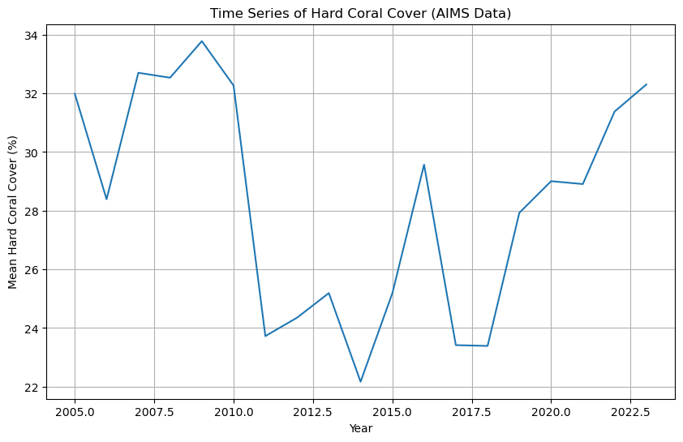

```python
# Load the coral cover dataset (cleaned Hard Coral only)
coral_df = load_coral_data("mmp_hc_sc_a_by_site.csv")

# Group the data by year and calculate mean Hard Coral cover for each year
annual_coral_cover = (
    coral_df.groupby("YEAR_CODE")["COVER"]
    .mean()
    .reset_index()
    .sort_values("YEAR_CODE"))

# Plot mean coral cover vs time
plt.figure(figsize=(10, 6))
plt.plot(annual_coral_cover["YEAR_CODE"], annual_coral_cover["COVER"])
plt.xlabel("Year")
plt.ylabel("Mean Hard Coral Cover (%)")
plt.title("Time Series of Hard Coral Cover (AIMS Data)")
plt.grid(True)
plt.show()
```

The assign_gbr_region function assigns each data point to a Great Barrier Reef region based on latitude, allowing coral and microplastic data to be grouped by geographic area. The safe_nonnegative function prevents numerical errors during model simulation by ensuring that coral cover and microplastic concentration never become negative. Together, these helper functions improve both the ecological interpretation and numerical stability of the model.

```python
def assign_gbr_region(lat):
    """Assign a Great Barrier Reef region based on latitude."""
    # Northern Great Barrier Reef
    if lat >= -14:
        return "Northern GBR"

    # Central Great Barrier Reef
    elif lat >= -20:
        return "Central GBR"

    # Southern Great Barrier Reef
    else:
        return "Southern GBR"


def safe_nonnegative(C, P):
    """Ensure variables remain non-negative during integration."""
    return max(C, 0.0), max(P, 0.0)
```

```python
# check assign
# Known latitude test cases
test_lats = [-10, -15, -18, -22, -30]

for lat in test_lats:
    print(f"Latitude {lat}: {assign_gbr_region(lat)}")
```

```
Latitude -10: Northern GBR
Latitude -15: Central GBR
Latitude -18: Central GBR
Latitude -22: Southern GBR
Latitude -30: Southern GBR
```

```python
# check nonnegative
test_values = [
    (0.5, 1.0),
    (-0.1, 0.3),
    (0.2, -5.0),
    (-1.0, -2.0)]

for C, P in test_values:
    print(f"Input (C,P)=({C},{P}) → Output {safe_nonnegative(C,P)}")
```

```
Input (C,P)=(0.5,1.0) → Output (0.5, 1.0)
Input (C,P)=(-0.1,0.3) → Output (0.0, 0.3)
Input (C,P)=(0.2,-5.0) → Output (0.2, 0.0)
Input (C,P)=(-1.0,-2.0) → Output (0.0, 0.0)
```

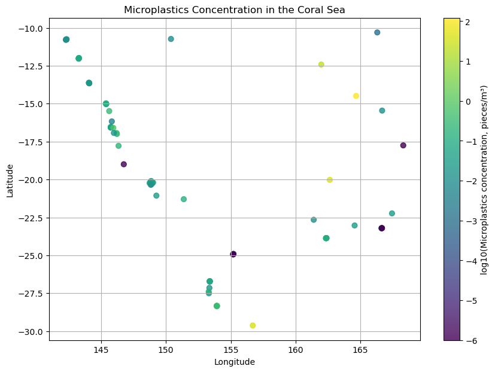

```python
# Load microplastics dataset
micro_df = load_microplastics_data("Marine_Microplastics_WGS84_6672910164286251904.csv")

# Convert longitude to numeric
micro_df["Longitude"] = pd.to_numeric(micro_df["Longitude(degree)"], errors="coerce")

# Drop rows missing longitude
micro_df = micro_df.dropna(subset=["Longitude"])

# Assign each observation to a GBR region
micro_df["GBR_region"] = micro_df["Latitude"].apply(assign_gbr_region)

# Extract variables
lon = micro_df["Longitude"]
lat = micro_df["Latitude"]
conc = micro_df["Microplastics"]

# Apply log transform to concentration values; no log(0)
log_conc = np.log10(conc + 1e-6)

# Plot of microplastic concentration
plt.figure(figsize=(10, 7))
scatter = plt.scatter(lon, lat, c=log_conc, s=40, alpha=0.8)

# Add colorbar
colorbar = plt.colorbar(scatter)
colorbar.set_label("log10(Microplastics concentration, pieces/m³)")

plt.xlabel("Longitude")
plt.ylabel("Latitude")
plt.title("Microplastics Concentration in the Coral Sea")
plt.grid(True)
plt.show()
```